# Tarea 3

Shantal Chavarría

2020-08-25

# Pregunta 1.

Suponga que trabajamos para un banco y se nos pide predecir el monto promedio de deuda en tarjeta de cr´edito de una cartera de clientes relativamente nuevos, basado en otra cartera de comportamiento y estructura similar de la cual sí se tiene información de deuda en tarjeta de crédito. En este ejercicio hacemos uso de la tabla de datos DeudaCredito.csv que contiene información de los clientes en una de las principales carteras de crédito del banco, e incluye variables que describen cada cliente tanto dentro del banco como fuera de este. Esta tabla de datos contiene 400 clientes y 11 variables que los describen. Seguidamente se explican las variables que conforman la tabla.

• Ingreso: Ingreso del cliente, en miles de dólares. • Limite: Límite de crédito global en tarjetas de crédito del cliente. • CalifCredit: Calificación crediticia del cliente. • Tarjetas: Cantidad de tarjetas de crédito del cliente. • Edad: Edad del cliente. • Educacion: Años de educación del cliente. • Genero: Género del cliente. • Estudiante: Indica si el cliente es estudiante o no. • Casado: Indica si el cliente es casado o no (1 = Sí, 0 = No). • Etnicidad: Indica si el cliente es caucásico, afroamericano o asiático. • Balance: Monto promedio de deuda en tarjeta de crédito del cliente, en dólares. Realice lo siguiente: ## 1. Cargue la tabla de datos en R y asegúrese que las variables se están leyendo de forma correcta. ¿Es necesario recodificar variables? Seleccione la variable a predecir, y tome para entrenamiento un 80 % de la tabla de datos.

```r
library(dplyr)
library(readr)
library(corrplot)

DeudaCredito <- read.table("Datos_EjemplosClase_Tarea/DeudaCredito.csv", sep = ",", header = TRUE)

DeudaCredito
```

| X | Ingreso | Limite | CalifCredit | Tarjetas | Edad | Educacion | Genero | Estudiante | Casado | Etnicidad | Balance |
| --- | --- | --- | --- | --- | --- | --- | --- | --- | --- | --- | --- |
| 1 | 14.891 | 3606 | 283 | 2 | 34 | 11 | Masculino | No | 1 | Caucasico | 333 |
| 2 | 106.025 | 6645 | 483 | 3 | 82 | 15 | Femenino | Si | 1 | Asiatico | 903 |
| 3 | 104.593 | 7075 | 514 | 4 | 71 | 11 | Masculino | No | 0 | Asiatico | 580 |
| 4 | 148.924 | 9504 | 681 | 3 | 36 | 11 | Femenino | No | 0 | Asiatico | 964 |
| 5 | 55.882 | 4897 | 357 | 2 | 68 | 16 | Masculino | No | 1 | Caucasico | 331 |
| 6 | 80.180 | 8047 | 569 | 4 | 77 | 10 | Masculino | No | 0 | Caucasico | 1151 |
| 7 | 20.996 | 3388 | 259 | 2 | 37 | 12 | Femenino | No | 0 | Afrodescendiente | 203 |
| 8 | 71.408 | 7114 | 512 | 2 | 87 | 9 | Masculino | No | 0 | Asiatico | 872 |
| 9 | 15.125 | 3300 | 266 | 5 | 66 | 13 | Femenino | No | 0 | Caucasico | 279 |
| 10 | 71.061 | 6819 | 491 | 3 | 41 | 19 | Femenino | Si | 1 | Afrodescendiente | 1350 |

[output cut: 65 more lines]

```r
str(DeudaCredito)
```

```
'data.frame':   400 obs. of  12 variables:
 $ X          : int  1 2 3 4 5 6 7 8 9 10 ...
 $ Ingreso    : num  14.9 106 104.6 148.9 55.9 ...
 $ Limite     : int  3606 6645 7075 9504 4897 8047 3388 7114 3300 6819 ...
 $ CalifCredit: int  283 483 514 681 357 569 259 512 266 491 ...
 $ Tarjetas   : int  2 3 4 3 2 4 2 2 5 3 ...
 $ Edad       : int  34 82 71 36 68 77 37 87 66 41 ...
 $ Educacion  : int  11 15 11 11 16 10 12 9 13 19 ...
 $ Genero     : chr  "Masculino" "Femenino" "Masculino" "Femenino" ...
 $ Estudiante : chr  "No" "Si" "No" "No" ...
 $ Casado     : int  1 1 0 0 1 0 0 0 0 1 ...
 $ Etnicidad  : chr  "Caucasico" "Asiatico" "Asiatico" "Asiatico" ...
 $ Balance    : int  333 903 580 964 331 1151 203 872 279 1350 ...
```

## 1.

Cargue la tabla de datos en R y asegúrese que las variables se están leyendo de forma correcta. ¿Es necesario recodificar variables? Seleccione la variable a predecir, y tome para entrenamiento un 80 % de la tabla de datos.

```r
library(dummies)
azar <- sample(1:nrow(DeudaCredito), nrow(DeudaCredito)*0.8)

DeudaCreditoCuantitativo <- dummy.data.frame(DeudaCredito, sep = ".")[,-1]

ochentaPorcentaje <- DeudaCreditoCuantitativo[azar,]

veintePorcentaje <- DeudaCreditoCuantitativo[-azar,]


#variable a predecir sería Balance
```

## 2.

Realice un Análisis Exploratorio de los datos con todos los datos que incluya al menos:

• summary(…).

```r
summary(DeudaCreditoCuantitativo)
```

```
    Ingreso           Limite       CalifCredit       Tarjetas
 Min.   : 10.35   Min.   :  855   Min.   : 93.0   Min.   :1.000
 1st Qu.: 21.01   1st Qu.: 3088   1st Qu.:247.2   1st Qu.:2.000
 Median : 33.12   Median : 4622   Median :344.0   Median :3.000
 Mean   : 45.22   Mean   : 4736   Mean   :354.9   Mean   :2.958
 3rd Qu.: 57.47   3rd Qu.: 5873   3rd Qu.:437.2   3rd Qu.:4.000
      Edad         Educacion     Genero.Femenino  Genero.Masculino
 Min.   :23.00   Min.   : 5.00   Min.   :0.0000   Min.   :0.0000
 1st Qu.:41.75   1st Qu.:11.00   1st Qu.:0.0000   1st Qu.:0.0000
 Median :56.00   Median :14.00   Median :1.0000   Median :0.0000
 Mean   :55.67   Mean   :13.45   Mean   :0.5175   Mean   :0.4825
 3rd Qu.:70.00   3rd Qu.:16.00   3rd Qu.:1.0000   3rd Qu.:1.0000
 Estudiante.No Estudiante.Si     Casado       Etnicidad.Afrodescendiente
 Min.   :0.0   Min.   :0.0   Min.   :0.0000   Min.   :0.0000
 1st Qu.:1.0   1st Qu.:0.0   1st Qu.:0.0000   1st Qu.:0.0000
 Median :1.0   Median :0.0   Median :1.0000   Median :0.0000
 Mean   :0.9   Mean   :0.1   Mean   :0.6125   Mean   :0.2475
 3rd Qu.:1.0   3rd Qu.:0.0   3rd Qu.:1.0000   3rd Qu.:0.0000
 Etnicidad.Asiatico Etnicidad.Caucasico    Balance
 Min.   :0.000      Min.   :0.0000      Min.   :   0.00
 1st Qu.:0.000      1st Qu.:0.0000      1st Qu.:  68.75
 Median :0.000      Median :0.0000      Median : 459.50
 Mean   :0.255      Mean   :0.4975      Mean   : 520.01
 3rd Qu.:1.000      3rd Qu.:1.0000      3rd Qu.: 863.00
 [ reached getOption("max.print") -- omitted 1 row ]
```

• La matriz de correlaciones y alguno de sus gráficos. Interprete al menos dos correlaciones.

```r
matriz.correlacion <- cor(DeudaCreditoCuantitativo)
matriz.correlacion
```

```
                               Ingreso       Limite  CalifCredit      Tarjetas
Ingreso                     1.00000000  0.792088341  0.791377625 -0.0182726097
Limite                      0.79208834  1.000000000  0.996879737  0.0102313330
CalifCredit                 0.79137763  0.996879737  1.000000000  0.0532390303
Tarjetas                   -0.01827261  0.010231333  0.053239030  1.0000000000
Edad                        0.17533840  0.100887922  0.103164996  0.0429482879
                                    Edad    Educacion Genero.Femenino
Ingreso                     0.1753384030 -0.027691982    -0.010737514
Limite                      0.1008879216 -0.023548534     0.009396678
CalifCredit                 0.1031649959 -0.030135627     0.008884590
Tarjetas                    0.0429482879 -0.051084217    -0.022658021
Edad                        1.0000000000  0.003619285     0.004015496
                           Genero.Masculino Estudiante.No Estudiante.Si
Ingreso                         0.010737514  -0.019632138   0.019632138
Limite                         -0.009396678   0.006015094  -0.006015094
CalifCredit                    -0.008884590   0.002027646  -0.002027646
Tarjetas                        0.022658021   0.026164127  -0.026164127
Edad                           -0.004015496   0.029844426  -0.029844426
                                Casado Etnicidad.Afrodescendiente
Ingreso                     0.03565236               0.0401320955
Limite                      0.03115483               0.0363199728
CalifCredit                 0.03675077               0.0375975522
Tarjetas                   -0.00969506               0.0008776802
Edad                       -0.07313550               0.0611692207
                           Etnicidad.Asiatico Etnicidad.Caucasico      Balance
Ingreso                          -0.017136707       -0.0197005823  0.463656457
Limite                           -0.032427478       -0.0030807498  0.861697267
CalifCredit                      -0.035999399       -0.0010697043  0.863625161
Tarjetas                          0.005591033       -0.0056314423  0.086456347
Edad                             -0.059622517       -0.0008220622  0.001835119
 [ reached getOption("max.print") -- omitted 10 rows ]
```

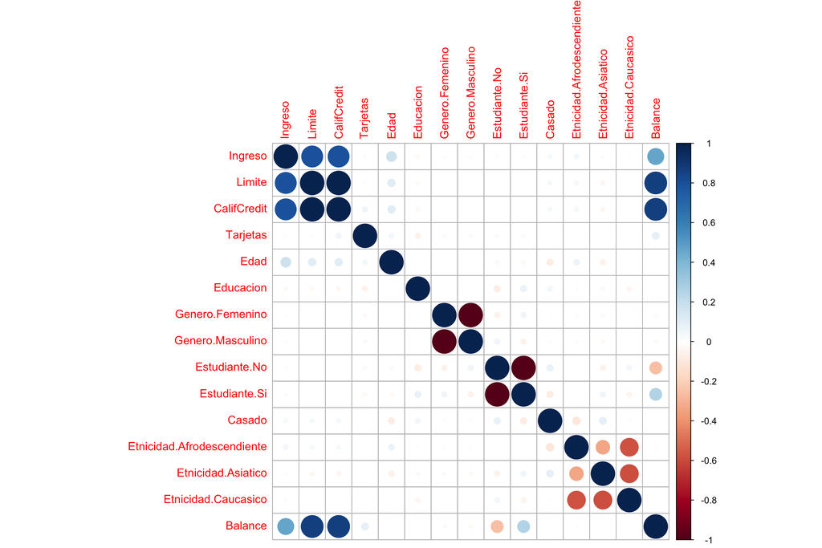

```r
corrplot(matriz.correlacion)
```

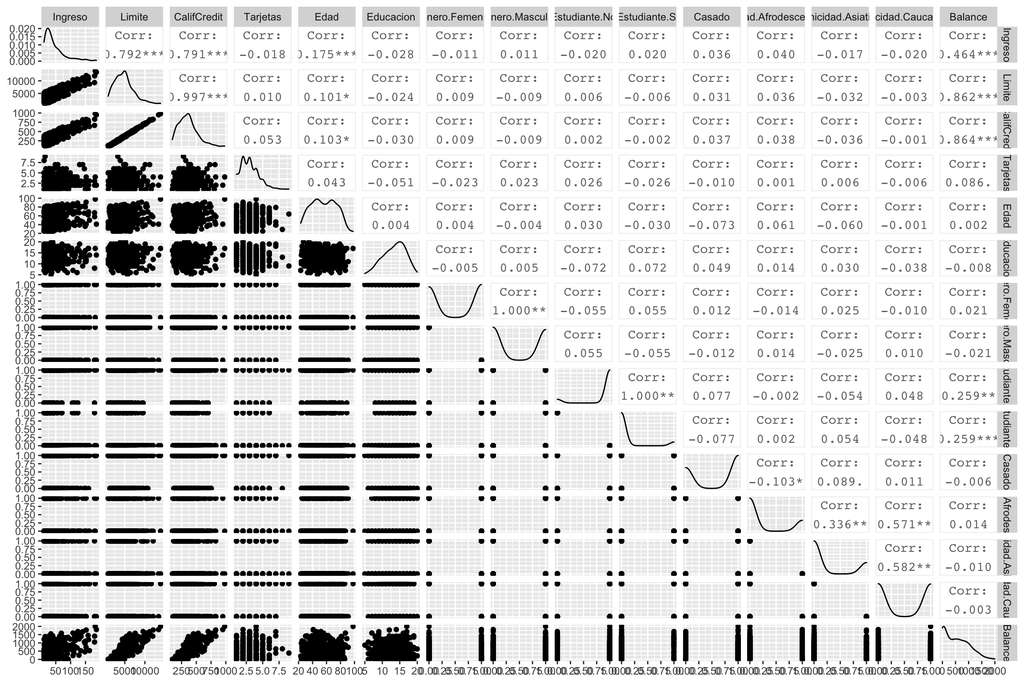

```r
ggpairs(DeudaCreditoCuantitativo)
```

• Encuentre al menos 3 datos atípicos, si es que existen en esta tabla de datos.

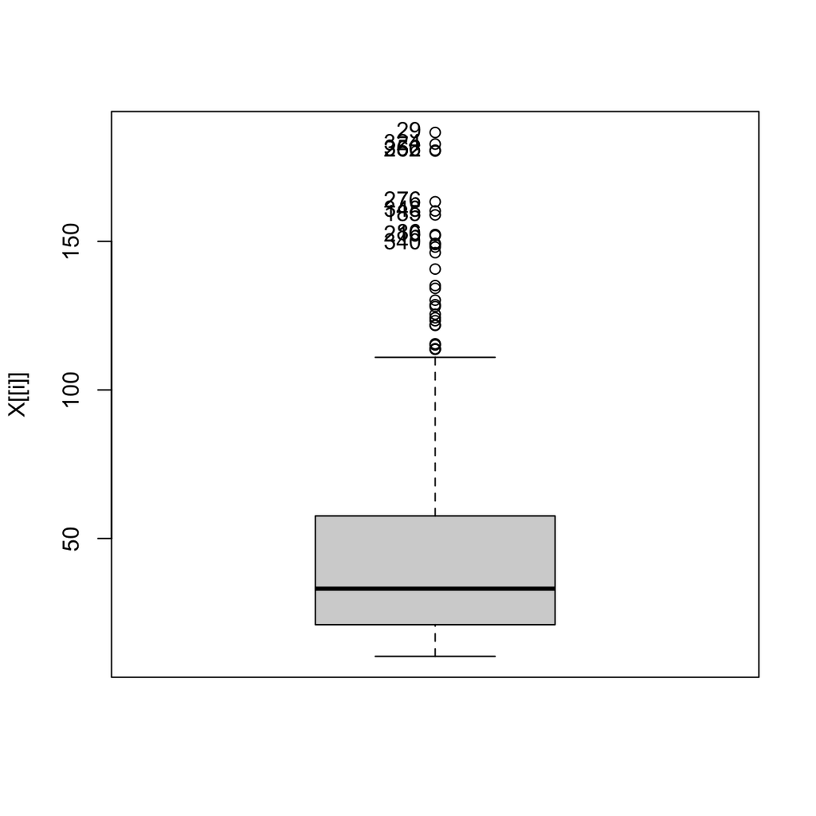

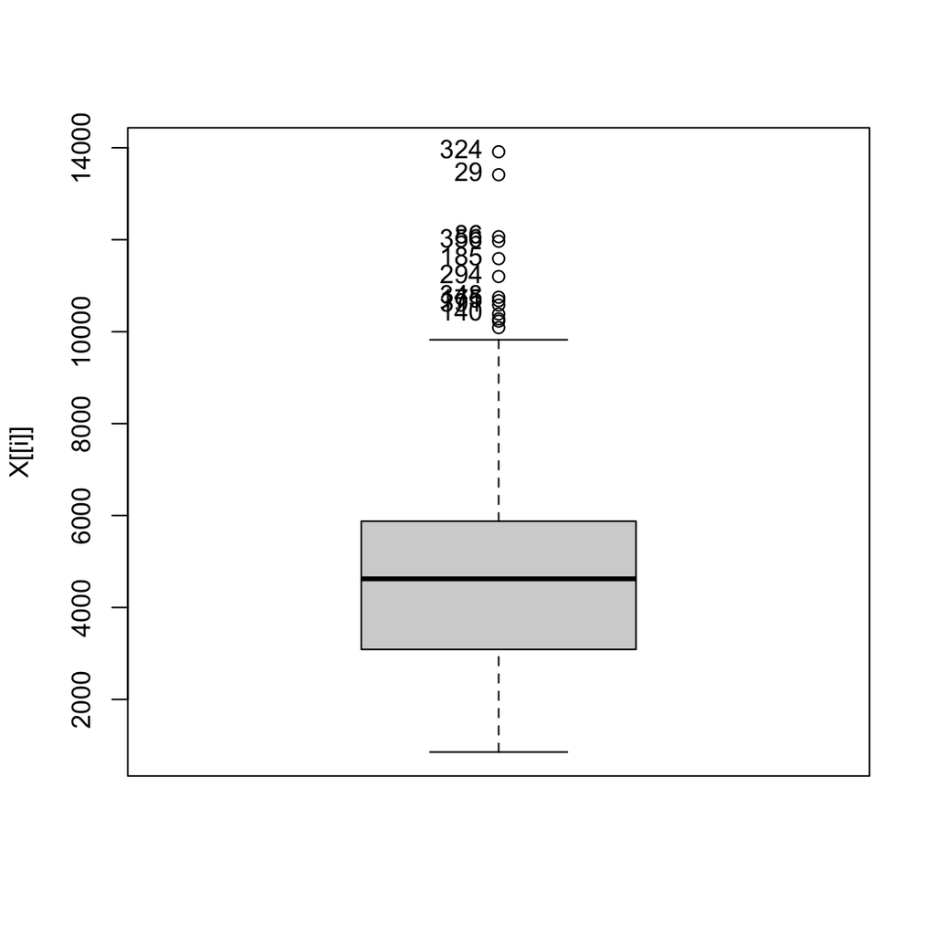

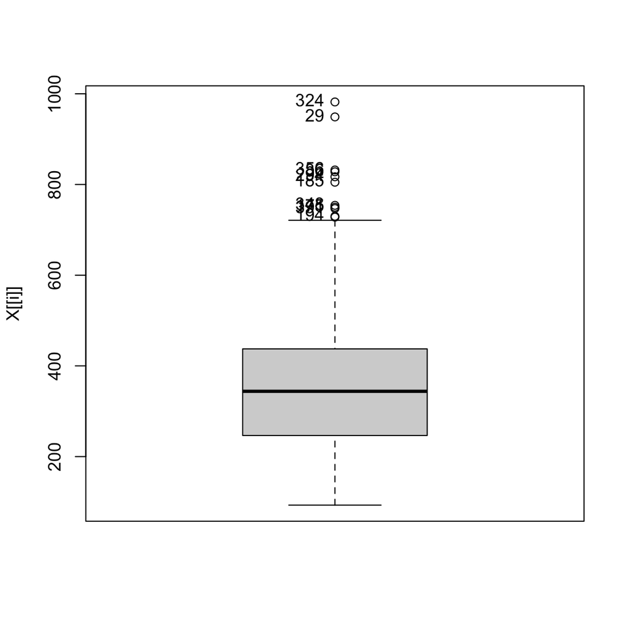

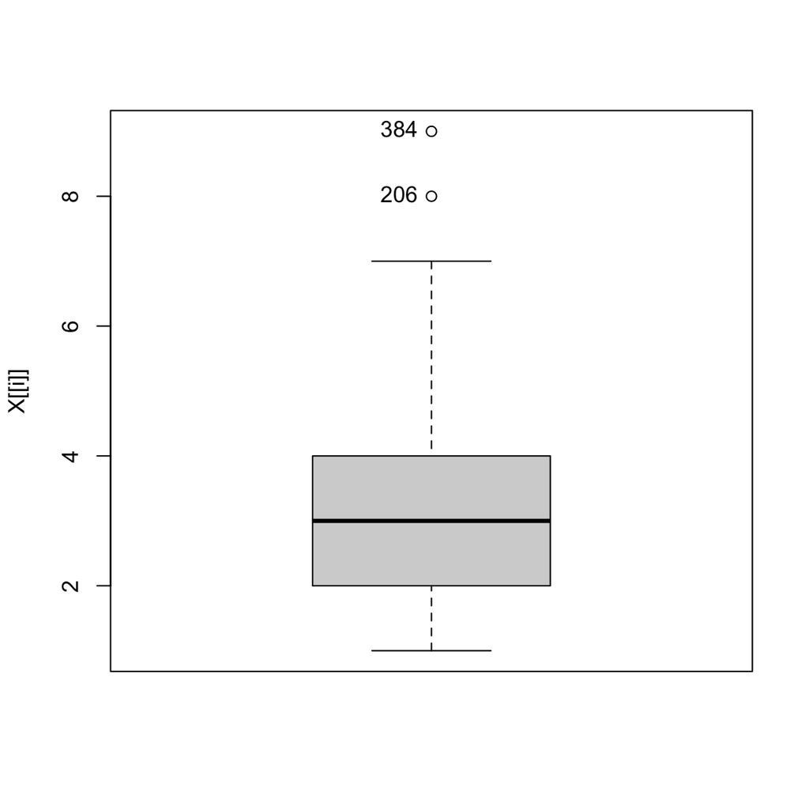

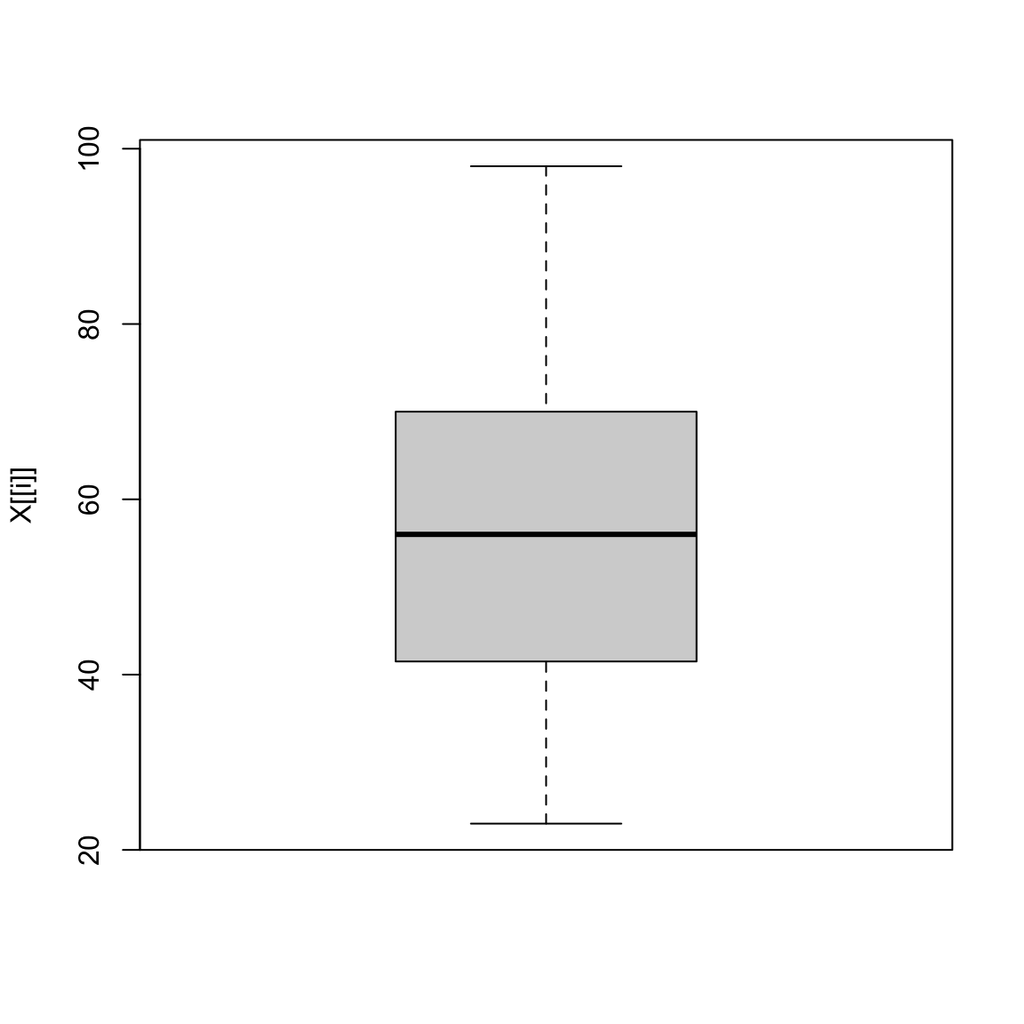

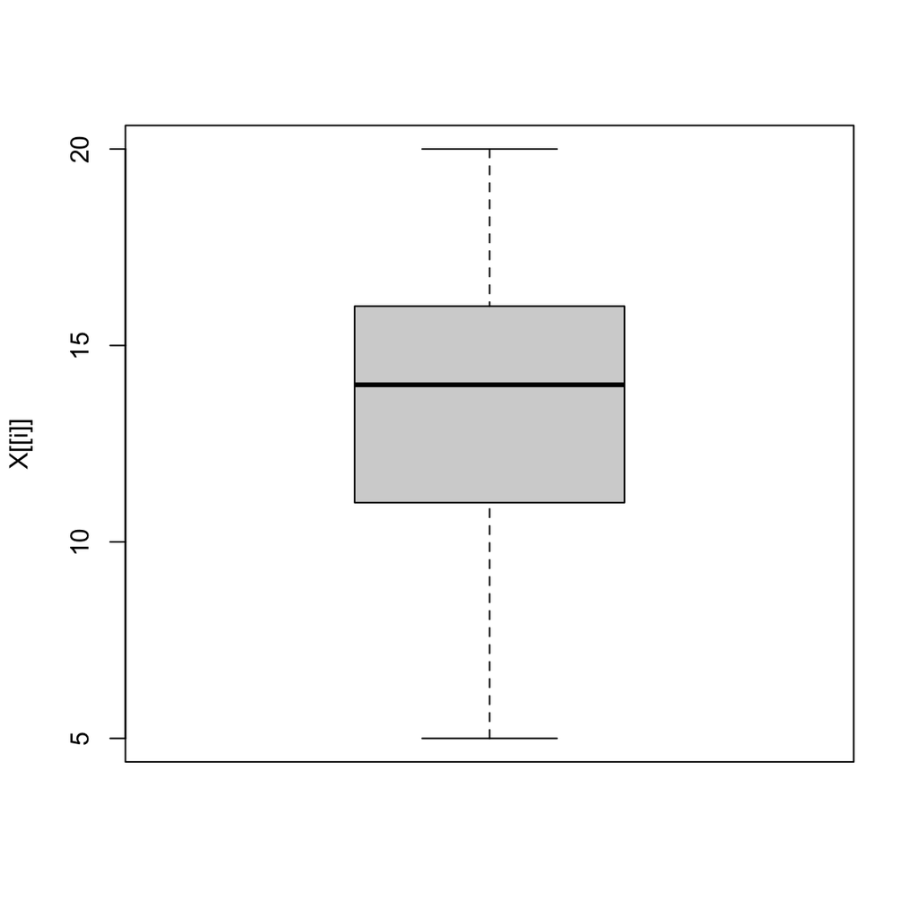

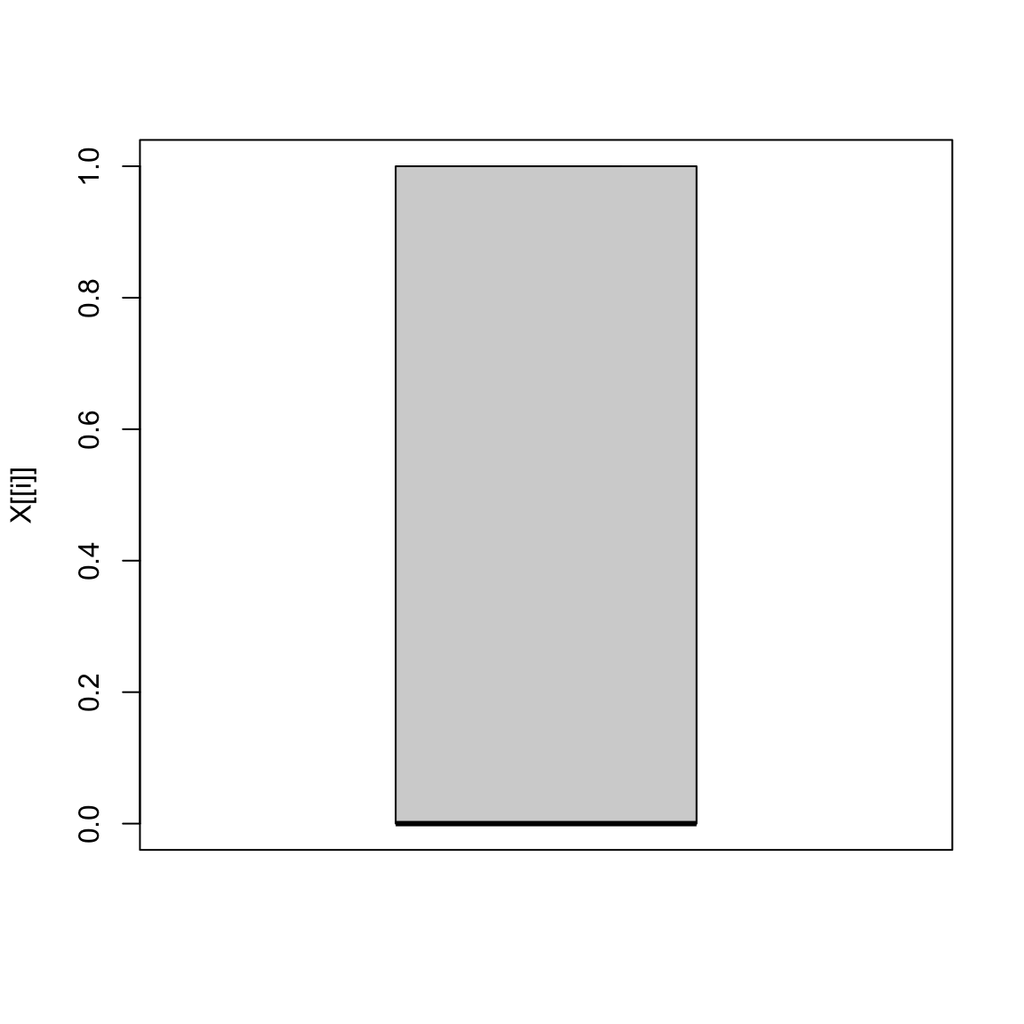

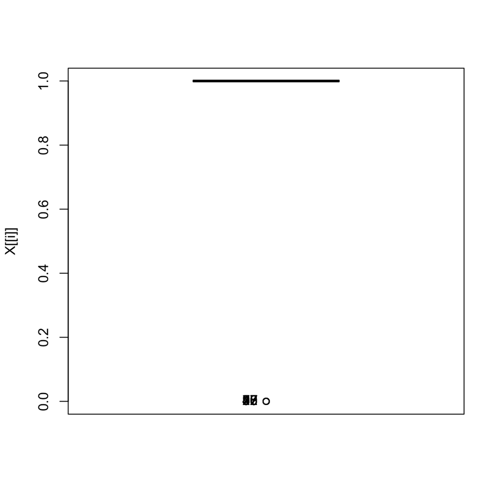

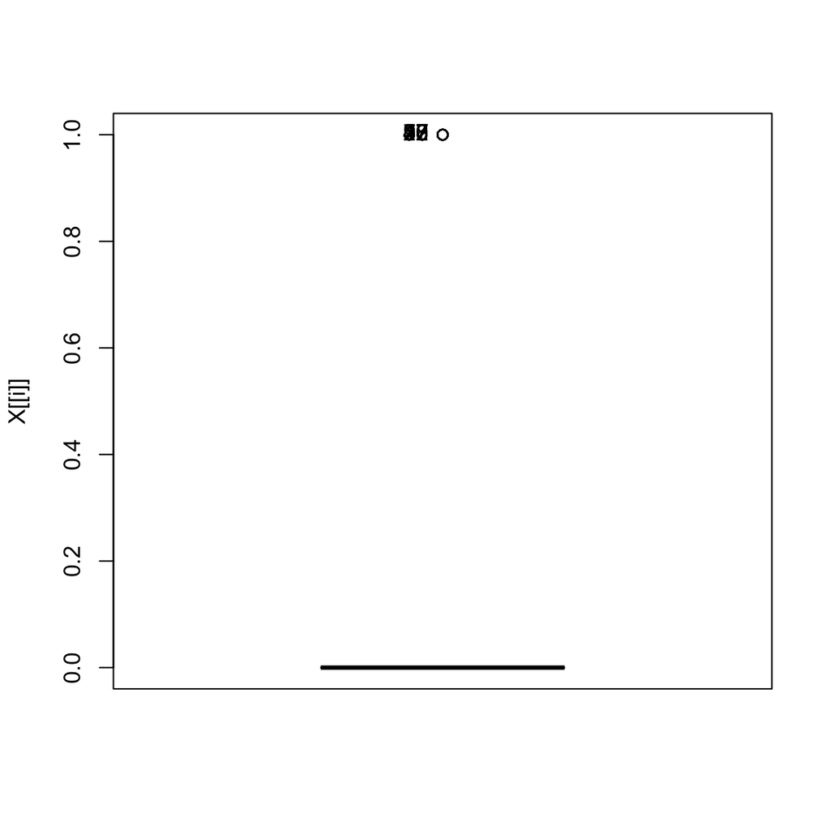

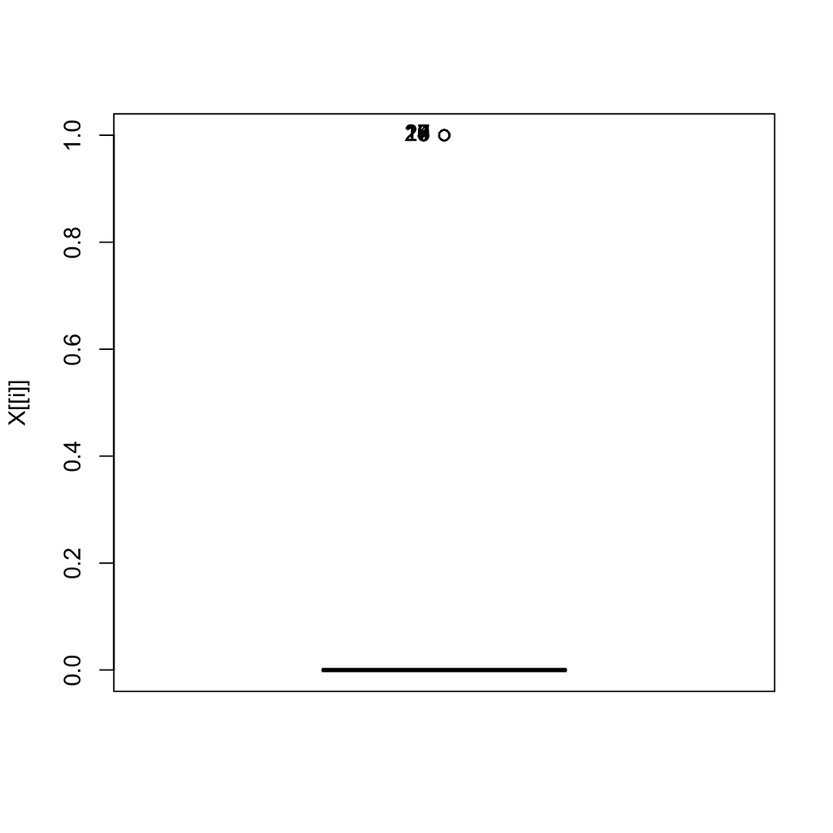

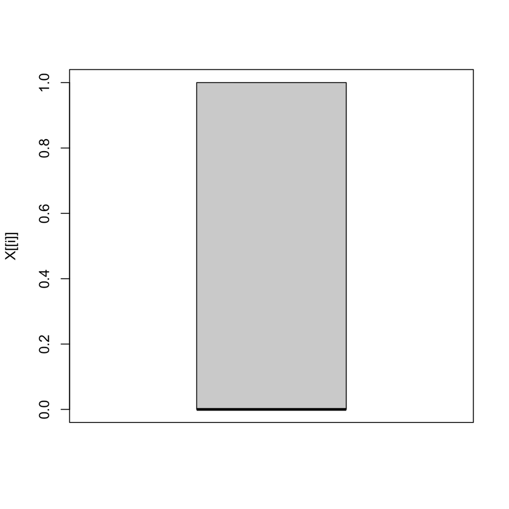

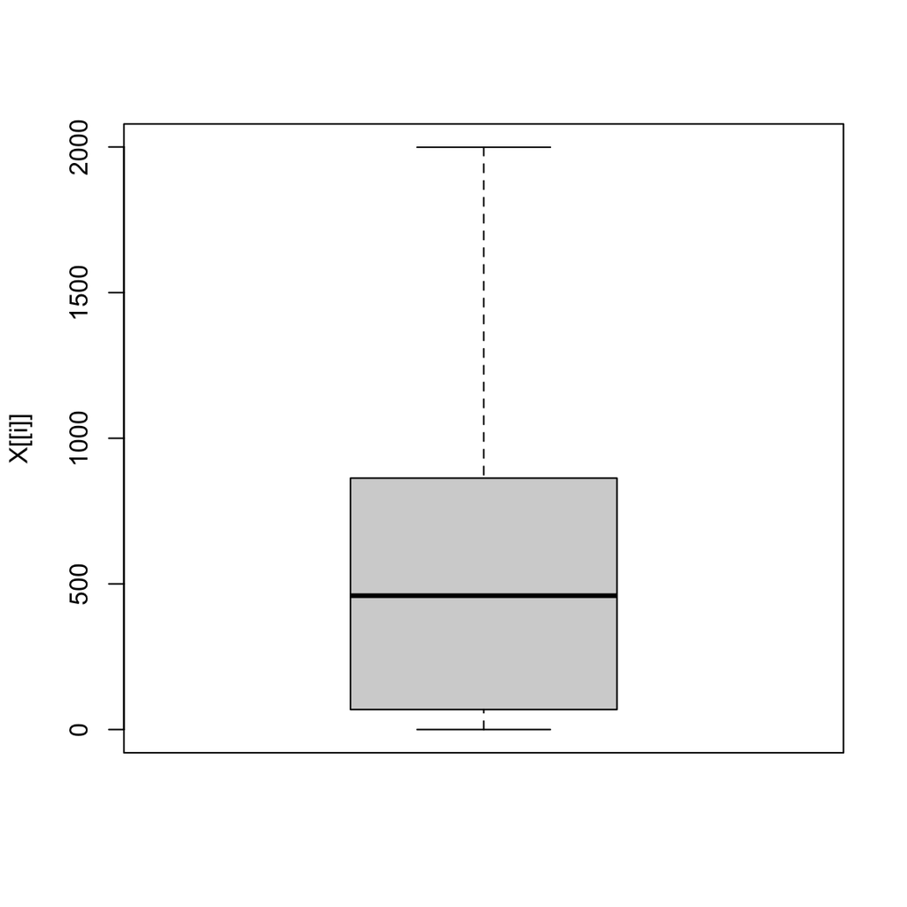

```
$Ingreso
 [1]  29 324 356 262 276 348 185  86 210 340

$Limite
 [1] 324  29  86 356 185 294 348 175 391 140

$CalifCredit
 [1] 324  29 356  86 294 185 348 175 391 194

$Tarjetas
[1] 206 384

$Estudiante.No
 [1]  2 10 27 36 42 47 48 50 77 97

$Estudiante.Si
 [1]  2 10 27 36 42 47 48 50 77 97

$Etnicidad.Afrodescendiente
 [1]  7 10 15 16 17 23 24 26 28 29
```

```r
library(car)
Filter(is.numeric,lapply(DeudaCreditoCuantitativo, Boxplot))
```

## 3.

Basado en las estadísticas básicas explique cuál variable numérica parece ser la mejor para predecir la deuda en tarjeta de crédito.

Basado en la matriz de correlaciones, diría que la variable del Limite o la Calificación de Credito tiene una correlación alta con el Balance.

## 4.

Genere un modelo de regresión lineal múltiple incluyendo las todas las variables predictoras. ¿Cuáles coeficientes obtiene para los β? Dé una interpretación de 3 de los coeficientes que se obtienen en el modelo. ¿Cuál variable parece tener más impacto sobre la variable a predecir y por qué?

```r
modelo <- lm(Balance ~ . , data = ochentaPorcentaje)
modelo
```

```
Call:
lm(formula = Balance ~ ., data = ochentaPorcentaje)

Coefficients:
               (Intercept)                     Ingreso
                  -35.1400                     -7.6135
                    Limite                 CalifCredit
                    0.1664                      1.4620
                  Tarjetas                        Edad
                   13.9299                     -0.5109
                 Educacion             Genero.Femenino
                   -1.7078                     -7.9579
          Genero.Masculino               Estudiante.No
                        NA                   -424.7379
             Estudiante.Si                      Casado
                        NA                    -13.1468
Etnicidad.Afrodescendiente          Etnicidad.Asiatico
                   -8.8004                      4.4624
       Etnicidad.Caucasico
                        NA
```

```r
summary(modelo)
```

```
Call:
lm(formula = Balance ~ ., data = ochentaPorcentaje)

Residuals:
    Min      1Q  Median      3Q     Max
-170.95  -80.44  -14.94   62.26  308.58

Coefficients: (3 not defined because of singularities)
                             Estimate Std. Error t value Pr(>|t|)
(Intercept)                 -35.14004   44.49134  -0.790  0.43024
Ingreso                      -7.61354    0.27107 -28.087  < 2e-16 ***
Limite                        0.16640    0.03967   4.195 3.57e-05 ***
CalifCredit                   1.46204    0.59211   2.469  0.01408 *
Tarjetas                     13.92991    5.12525   2.718  0.00694 **
Edad                         -0.51093    0.33292  -1.535  0.12589
Educacion                    -1.70784    1.84325  -0.927  0.35489
Genero.Femenino              -7.95794   11.38073  -0.699  0.48493
Genero.Masculino                   NA         NA      NA       NA
Estudiante.No              -424.73795   19.67077 -21.592  < 2e-16 ***
Estudiante.Si                      NA         NA      NA       NA
Casado                      -13.14678   11.96021  -1.099  0.27254
Etnicidad.Afrodescendiente   -8.80042   14.16231  -0.621  0.53480
Etnicidad.Asiatico            4.46245   13.95673   0.320  0.74939
Etnicidad.Caucasico                NA         NA      NA       NA
---
Signif. codes:  0 '***' 0.001 '**' 0.01 '*' 0.05 '.' 0.1 ' ' 1

Residual standard error: 101.2 on 308 degrees of freedom
Multiple R-squared:  0.9541,    Adjusted R-squared:  0.9525
F-statistic: 582.5 on 11 and 308 DF,  p-value: < 2.2e-16
```

El R2 es cercano a 1 por lo que tenemos un buen modelo de prediccion. Observando el p- value de Ingreso, Límite y CalifCredit tiene una buena probabilidad

##4. ¿Qué error se obtiene sobre la tabla de testing para el modelo de regresión lineal? Interprete las medidas de error obtenidas.

```r
RSS <- function(Pred,Real) {
  ss <- sum((Real-Pred)^2)
  return(ss)
}

RSE<-function(Pred,Real,NumPred) {
  N<-length(Real)-NumPred-1  # <- length(Real)-(NumPred+1)
  ss<-sqrt((1/N)*RSS(Pred,Real))
  return(ss)
}

MSE <- function(Pred,Real) {
  N<-length(Real)
  ss<-(1/N)*RSS(Pred,Real)
  return(ss)
}

error.relativo <- function(Pred,Real) {
  ss<-sum(abs(Real-Pred))/sum(abs(Real))
  return(ss)
}

indices.precision <- function(real, prediccion,cantidad.variables.predictoras) {
  return(list(error.cuadratico = MSE(prediccion,real),
              raiz.error.cuadratico = RSE(prediccion,real,cantidad.variables.predictoras),
              error.relativo = error.relativo(prediccion,real),
              correlacion = as.numeric(cor(prediccion,real))))
}

numero.predictoras <- dim(DeudaCreditoCuantitativo)[2] - 1
#Usando los datos del 80%

modelo.lm <- lm(Balance~ ., data = ochentaPorcentaje)
modelo.lm
```

```
Call:
lm(formula = Balance ~ ., data = ochentaPorcentaje)

Coefficients:
               (Intercept)                     Ingreso
                  -35.1400                     -7.6135
                    Limite                 CalifCredit
                    0.1664                      1.4620
                  Tarjetas                        Edad
                   13.9299                     -0.5109
                 Educacion             Genero.Femenino
                   -1.7078                     -7.9579
          Genero.Masculino               Estudiante.No
                        NA                   -424.7379
             Estudiante.Si                      Casado
                        NA                    -13.1468
Etnicidad.Afrodescendiente          Etnicidad.Asiatico
                   -8.8004                      4.4624
       Etnicidad.Caucasico
                        NA
```

```r
prediccion <- predict(modelo.lm, Filter(is.numeric, veintePorcentaje))

pre.lm <- indices.precision(veintePorcentaje$Balance, prediccion, numero.predictoras)

pre.lm
```

```
$error.cuadratico
[1] 8180.411

$raiz.error.cuadratico
[1] 100.3404

$error.relativo
[1] 0.1431218

$correlacion
[1] 0.9793922
```

## 6.

Si tuviera que eliminar alguna o algunas de las variables con la esperanza de que mejore la predicción ¿Cuál o cuáles de las variables eliminaría? ¿El nuevo modelo mejora la predicción?

Viendo la matriz de correlaciones parece que las variables que se relacionan en menor magnitud con Balance son Edad y Educación. Sin embargo el nuevo modelo hay una diferencia menor pero no significativa

```r
test <- DeudaCreditoCuantitativo[-c(5,6)]

summary(lm(Balance~. , test))
```

```
Call:
lm(formula = Balance ~ ., data = test)

Residuals:
    Min      1Q  Median      3Q     Max
-176.67  -76.50  -10.15   55.38  332.72

Coefficients: (3 not defined because of singularities)
                            Estimate Std. Error t value Pr(>|t|)
(Intercept)                 -91.0860    26.7076  -3.410 0.000716 ***
Ingreso                      -7.8797     0.2319 -33.973  < 2e-16 ***
Limite                        0.1902     0.0328   5.798 1.38e-08 ***
CalifCredit                   1.1550     0.4912   2.351 0.019206 *
Tarjetas                     17.3904     4.3542   3.994 7.77e-05 ***
Genero.Femenino             -10.8609     9.9490  -1.092 0.275661
Genero.Masculino                  NA         NA      NA       NA
Estudiante.No              -426.2112    16.7148 -25.499  < 2e-16 ***
Estudiante.Si                     NA         NA      NA       NA
Casado                       -7.3422    10.3493  -0.709 0.478473
Etnicidad.Afrodescendiente  -11.1880    12.2434  -0.914 0.361386
Etnicidad.Asiatico            7.4336    12.1552   0.612 0.541188
Etnicidad.Caucasico               NA         NA      NA       NA
---
Signif. codes:  0 '***' 0.001 '**' 0.01 '*' 0.05 '.' 0.1 ' ' 1

Residual standard error: 99.16 on 390 degrees of freedom
Multiple R-squared:  0.9545,    Adjusted R-squared:  0.9535
F-statistic: 909.8 on 9 and 390 DF,  p-value: < 2.2e-16
```

# Pregunta 2:

Un cliente nos contrata para estudiar una posible oportunidad de negocio, y para ver si le es rentable quiere una predicci´on de las ventas potenciales de asientos de ni˜nos para autos en su tienda. Para ello hacemos uso de los datos AsientosNinno.csv los cual contienen detalles de ventas de asientos de ni˜nos para auto en una serie de tiendas similares a las del cliente, y adem´as los datos incluyen variables que definen caracter´ısticas de la tienda y su localidad. La tabla de datos est´a formada por 400 filas y 11 columnas. Seguidamente se explican las variables que conforman la tabla. • Ventas: Ventas de asientos de ni˜nos para autos en cada localidad, en miles de unidades. • PrecioCompt: Precio promedio por asiento de ni˜no cobrado por la competencia en cada localidad. • Ingreso: Nivel de ingreso promedio de los habitantes de la regi´on, en miles de d´olares. • Publicidad: Presupuesto que asigna cada tienda a publicidad, en miles de d´olares. • Poblacion: Tama˜no de la poblaci´on en cada regi´on, en miles. • Precio: Precio cobrado por la tienda por los asientos de ni˜no para auto. • CalidadEstant: Indica la calidad de ubicaci´on de los asientos de ni˜no en los estantes de la tienda. • Edad: Edad promedio de los habitantes de la localidad. • Educacion: A˜nos de educaci´on promedio de los habitantes de cada regi´on. • Urbano: Indica si la tienda est´a localizada en una zona urbana o no (1 = S´ı, 0 = No). • USA: Indica si la tienda est´a ubicada en Estados Unidos o no (1 = S´ı, 0 = No).

Realice lo siguiente:

## 1.

Cargue la tabla de datos en R. En caso de ser necesario, recodificar las variables de forma adecuada. Seleccione la variable a predecir, y para medir el error tome un 15 % de la tabla de datos.

En este caso Ventas sería la variable a predecir

```r
AsientosNinno <- read_delim("Datos_EjemplosClase_Tarea/AsientosNinno.csv",
    ";", escape_double = FALSE, trim_ws = TRUE)

AsientosNinno <- data.frame(AsientosNinno)

AsientosNinno$CalidadEstant <- as.factor(AsientosNinno$CalidadEstant)

AsientosNinnoCuantitativo <- dummy.data.frame(AsientosNinno, sep = ";")[,-1]

azar <- sample(1:nrow(AsientosNinnoCuantitativo), nrow(AsientosNinnoCuantitativo)*0.85)

ochentacincoPorcentaje <- AsientosNinnoCuantitativo[azar,]

quincePorcentaje <- AsientosNinnoCuantitativo[-azar,]
```

## 2.

Realice un Análisis Exploratorio de los datos con todos los datos que incluya al menos: • summary(…).

```r
summary(AsientosNinnoCuantitativo)
```

```
     Ventas        PrecioCompt     Ingreso         Publicidad
 Min.   : 0.000   Min.   : 77   Min.   : 21.00   Min.   : 0.000
 1st Qu.: 5.390   1st Qu.:115   1st Qu.: 42.75   1st Qu.: 0.000
 Median : 7.490   Median :125   Median : 69.00   Median : 5.000
 Mean   : 7.496   Mean   :125   Mean   : 68.66   Mean   : 6.635
 3rd Qu.: 9.320   3rd Qu.:135   3rd Qu.: 91.00   3rd Qu.:12.000
   Poblacion         Precio      CalidadEstant;Bueno CalidadEstant;Malo
 Min.   : 10.0   Min.   : 24.0   Min.   :0.0000      Min.   :0.00
 1st Qu.:139.0   1st Qu.:100.0   1st Qu.:0.0000      1st Qu.:0.00
 Median :272.0   Median :117.0   Median :0.0000      Median :0.00
 Mean   :264.8   Mean   :115.8   Mean   :0.2125      Mean   :0.24
 3rd Qu.:398.5   3rd Qu.:131.0   3rd Qu.:0.0000      3rd Qu.:0.00
 CalidadEstant;Medio      Edad         Educacion        Urbano
 Min.   :0.0000      Min.   :25.00   Min.   :10.0   Min.   :0.000
 1st Qu.:0.0000      1st Qu.:39.75   1st Qu.:12.0   1st Qu.:0.000
 Median :1.0000      Median :54.50   Median :14.0   Median :1.000
 Mean   :0.5475      Mean   :53.32   Mean   :13.9   Mean   :0.705
 3rd Qu.:1.0000      3rd Qu.:66.00   3rd Qu.:16.0   3rd Qu.:1.000
      USA
 Min.   :0.000
 1st Qu.:0.000
 Median :1.000
 Mean   :0.645
 3rd Qu.:1.000
 [ reached getOption("max.print") -- omitted 1 row ]
```

• La matriz de correlaciones y alguno de sus gráficos. Interprete al menos dos correlaciones.

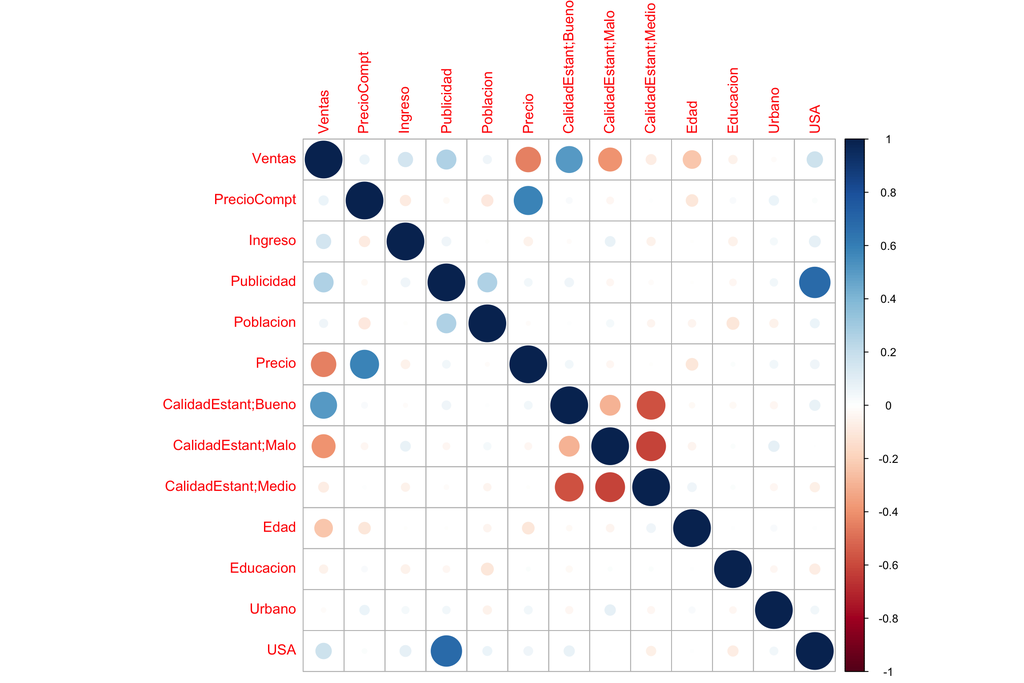

```r
matriz.correlaciones <- cor(AsientosNinnoCuantitativo)

corrplot(matriz.correlaciones)
```

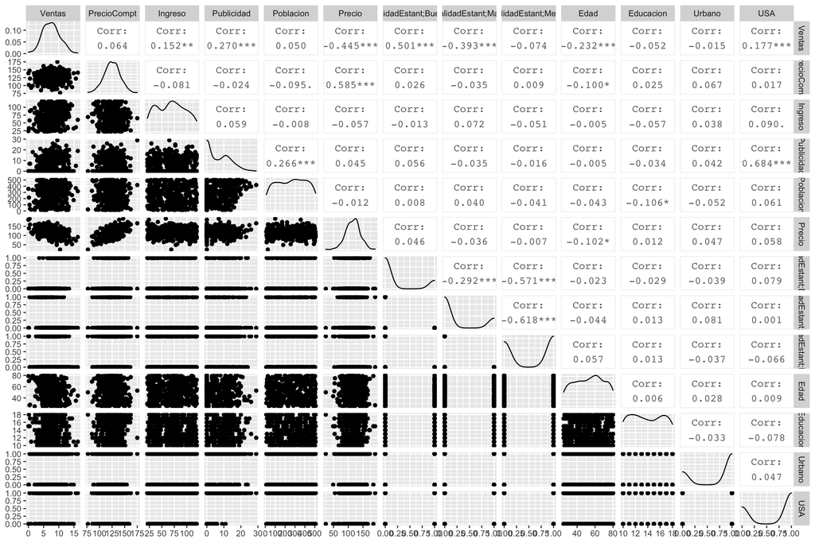

```r
ggpairs(AsientosNinnoCuantitativo)
```

• Encuentre al menos 3 datos atípicos, si es que existen en esta tabla de datos

Las variables de Ventas, PrecioCompt y Precio tienen valores atípicos.

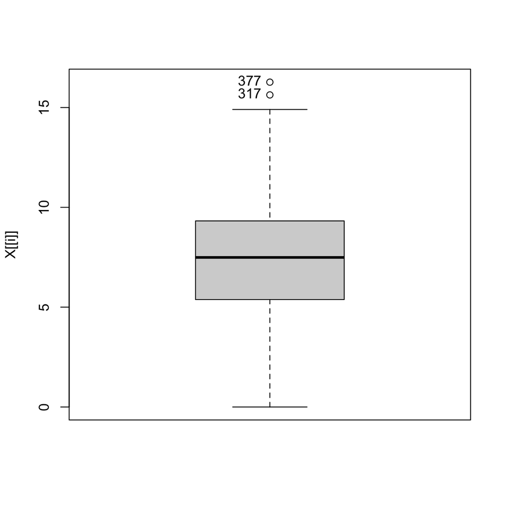

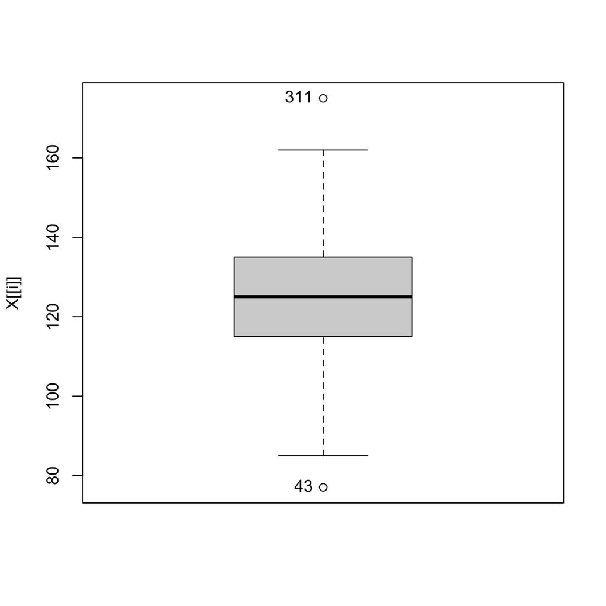

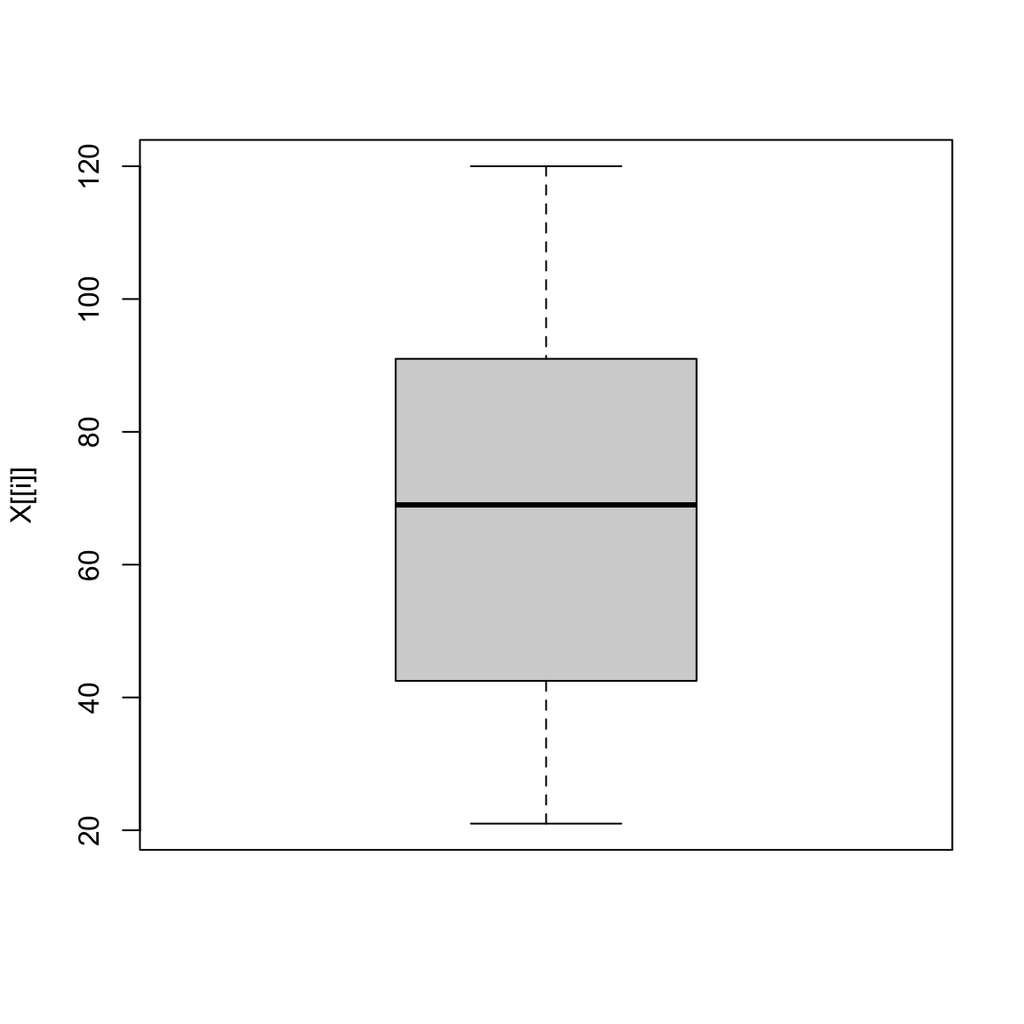

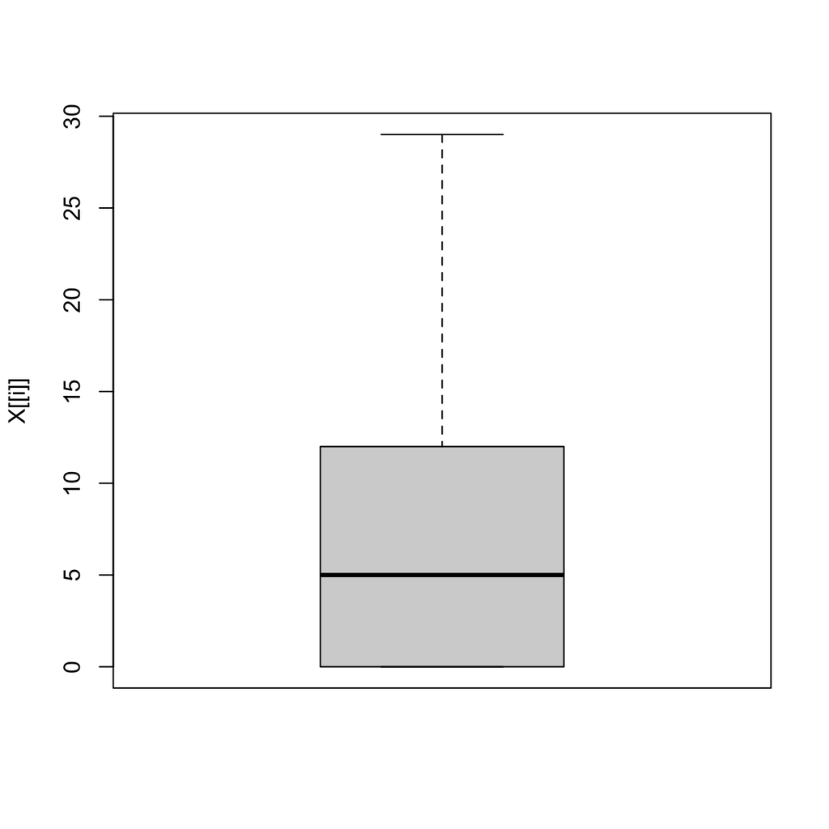

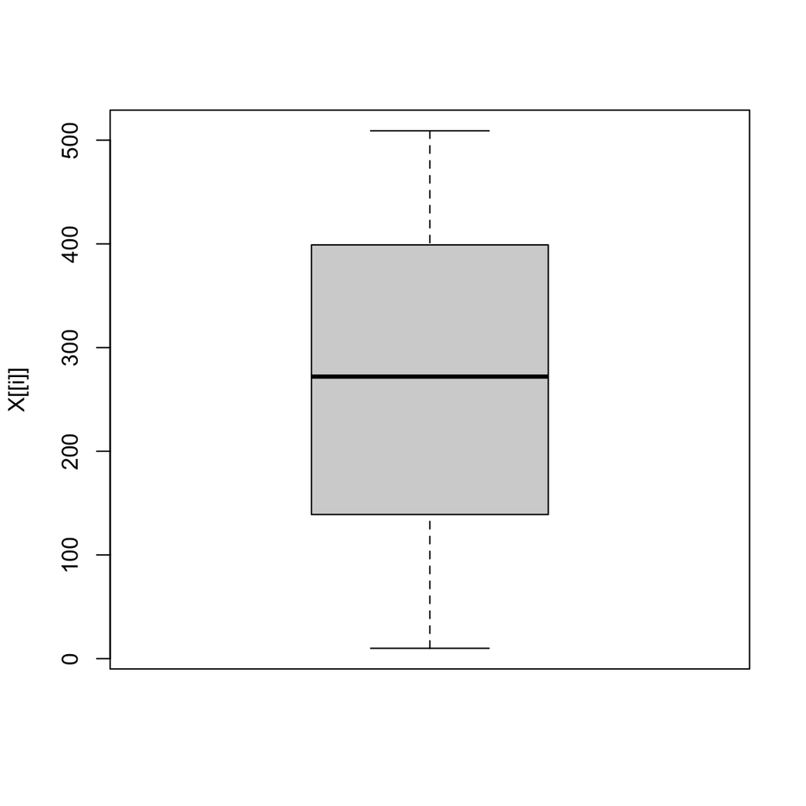

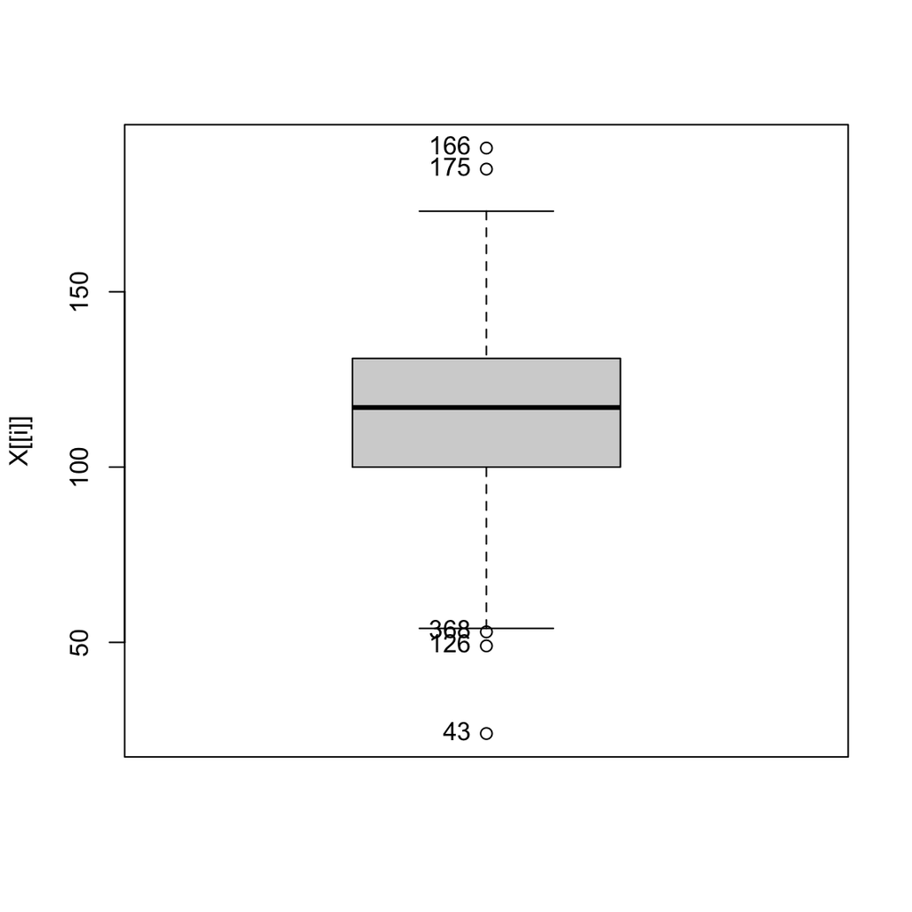

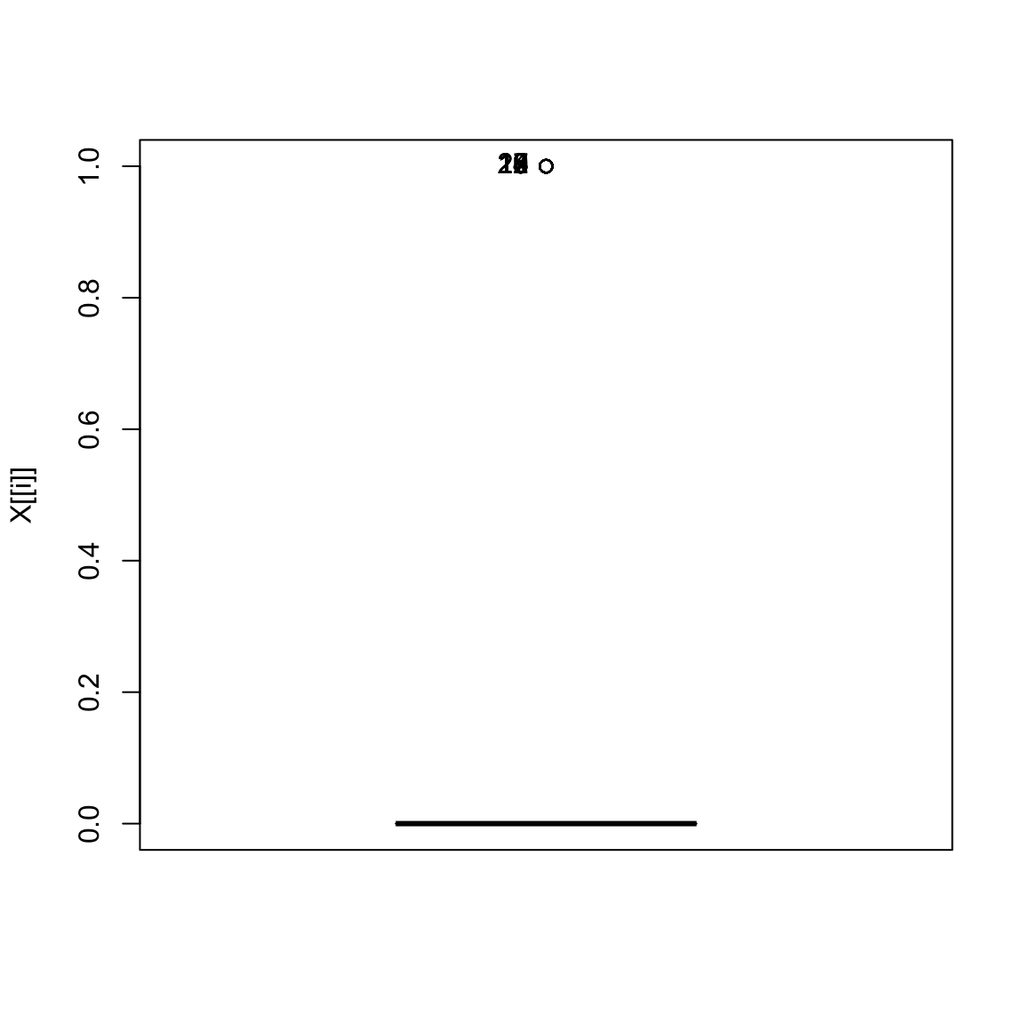

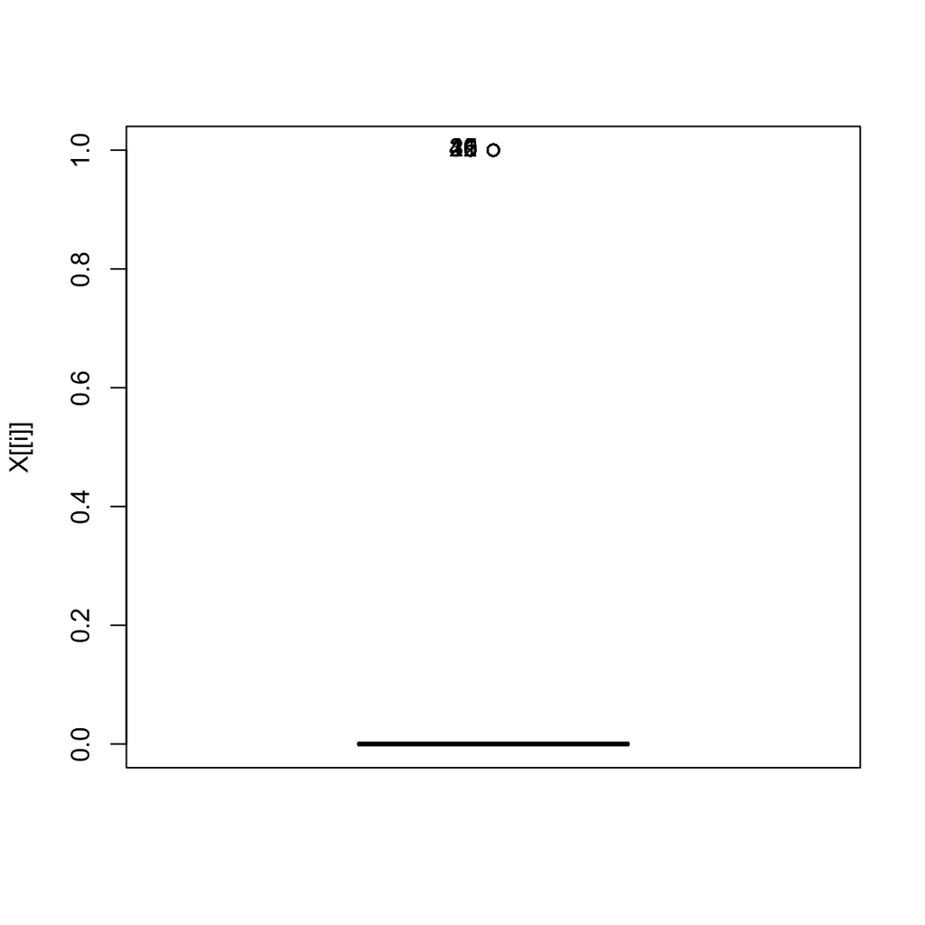

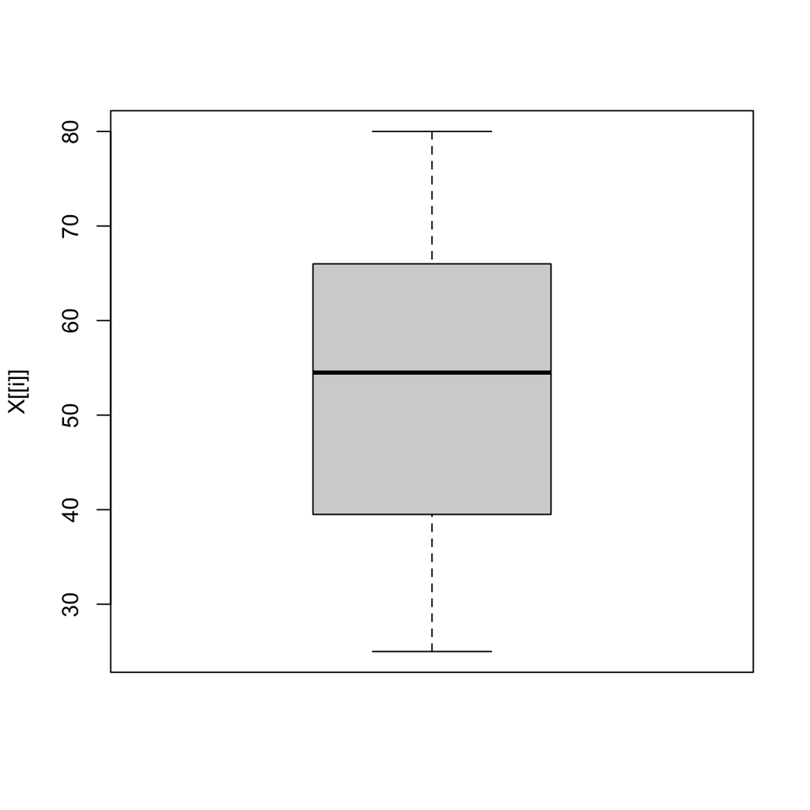

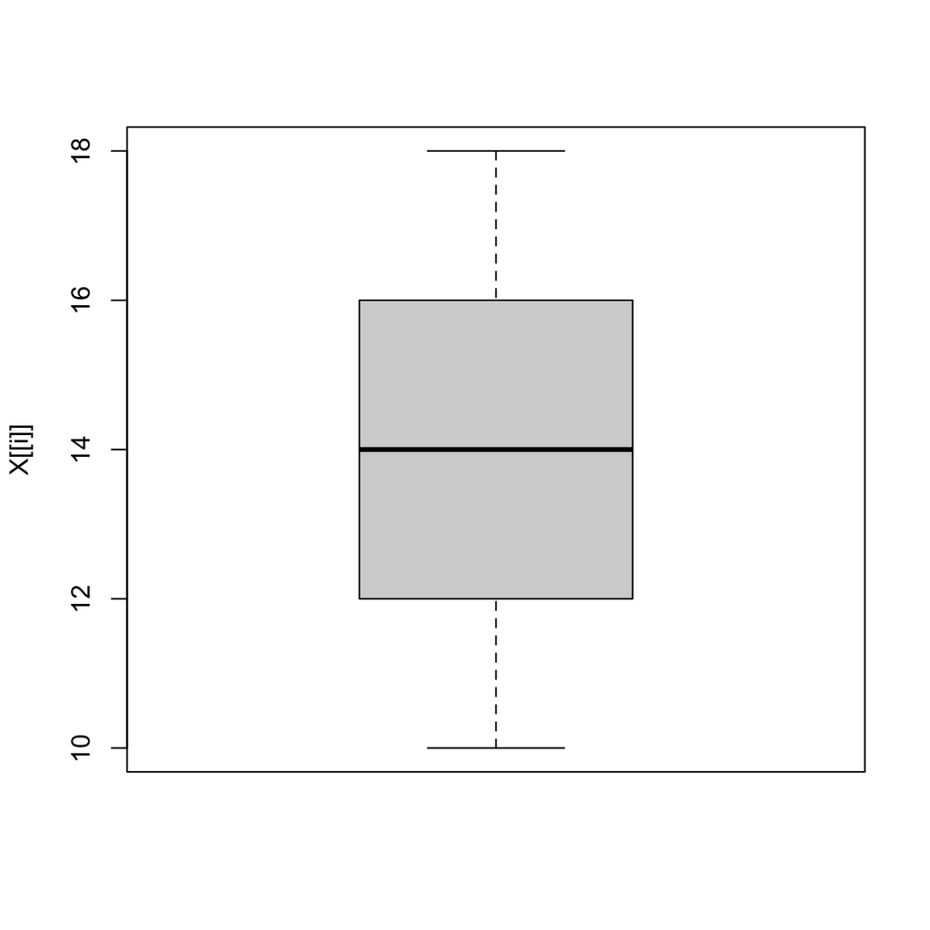

```
$Ventas
[1] 317 377

$PrecioCompt
[1]  43 311

$Ingreso
NULL

$Publicidad
NULL

$Poblacion
NULL

$Precio
[1]  43 126 368 166 175

$`CalidadEstant;Bueno`
 [1]  2  8 12 14 15 17 18 19 22 26

$`CalidadEstant;Malo`
 [1]  1  5  6 11 25 29 30 40 41 42

$`CalidadEstant;Medio`
NULL

$Edad
NULL

$Educacion
NULL

$Urbano
NULL

$USA
NULL
```

```r
lapply(AsientosNinnoCuantitativo,Boxplot)
```

## 3.

Aplique el modelo de regresi´on lineal m´ultiple incluyendo todas las variables predictoras.

```r
modelo <- lm(Ventas ~ . , data = ochentacincoPorcentaje)
modelo
```

```
Call:
lm(formula = Ventas ~ ., data = ochentacincoPorcentaje)

Coefficients:
          (Intercept)            PrecioCompt                Ingreso
            7.7761916              0.0909549              0.0163507
           Publicidad              Poblacion                 Precio
            0.1235575              0.0002666             -0.0955852
`CalidadEstant;Bueno`   `CalidadEstant;Malo`  `CalidadEstant;Medio`
            2.9147792             -2.0033070                     NA
                 Edad              Educacion                 Urbano
           -0.0477111             -0.0181725              0.1636421
                  USA
           -0.0791215
```

```r
summary(modelo)
```

```
Call:
lm(formula = Ventas ~ ., data = ochentacincoPorcentaje)

Residuals:
    Min      1Q  Median      3Q     Max
-2.8561 -0.6647  0.0166  0.6343  3.2700

Coefficients: (1 not defined because of singularities)
                        Estimate Std. Error t value Pr(>|t|)
(Intercept)            7.7761916  0.6535145  11.899  < 2e-16 ***
PrecioCompt            0.0909549  0.0045032  20.198  < 2e-16 ***
Ingreso                0.0163507  0.0019811   8.253  3.8e-15 ***
Publicidad             0.1235575  0.0117864  10.483  < 2e-16 ***
Poblacion              0.0002666  0.0003985   0.669    0.504
Precio                -0.0955852  0.0028918 -33.054  < 2e-16 ***
`CalidadEstant;Bueno`  2.9147792  0.1421954  20.498  < 2e-16 ***
`CalidadEstant;Malo`  -2.0033070  0.1335448 -15.001  < 2e-16 ***
`CalidadEstant;Medio`         NA         NA      NA       NA
Edad                  -0.0477111  0.0033991 -14.036  < 2e-16 ***
Educacion             -0.0181725  0.0213743  -0.850    0.396
Urbano                 0.1636421  0.1210244   1.352    0.177
USA                   -0.0791215  0.1608940  -0.492    0.623
---
Signif. codes:  0 '***' 0.001 '**' 0.01 '*' 0.05 '.' 0.1 ' ' 1

Residual standard error: 1.007 on 328 degrees of freedom
Multiple R-squared:  0.8837,    Adjusted R-squared:  0.8798
F-statistic: 226.6 on 11 and 328 DF,  p-value: < 2.2e-16
```

## 4.

¿Qué error se obtiene sobre la tabla de training para el modelo generado anteriormente?

```r
numero.predictoras <- dim(AsientosNinnoCuantitativo)[2] - 1

#Usando los datos del 80%
prediccion <- predict(modelo, Filter(is.numeric, quincePorcentaje)[,-1])

pre.lm <- indices.precision(quincePorcentaje$Precio, prediccion, numero.predictoras)

pre.lm
```

```
$error.cuadratico
[1] 11772.33

$raiz.error.cuadratico
[1] 122.5908

$error.relativo
[1] 0.9327573

$correlacion
[1] -0.5197883
```

# Pregunta 3:

La Tabla de Datos uscrime.csv contiene el cálculo de índice de crímenes violentos por habitante en Estados Unidos, como son el asesinato, la violación, el robo y asalto. Las variables incluidas son, entre otras, el porcentaje de la población considerada urbana, la renta media de la familia, la participación de las fuerzas del orden, el número de policías per cápita, el porcentaje de los oficiales asignados a las unidades de la droga. La variable a predecir es ViolentCrimesPerPop (Per Capita Violent Crimes in US). Usando un 67 % de esta tabla para Tabla de Aprendizaje y el restante 33 % para Tabla de Testing efectue lo siguiente:

## 1.

Realice un Análisis Exploratorio de los datos con todos los datos.

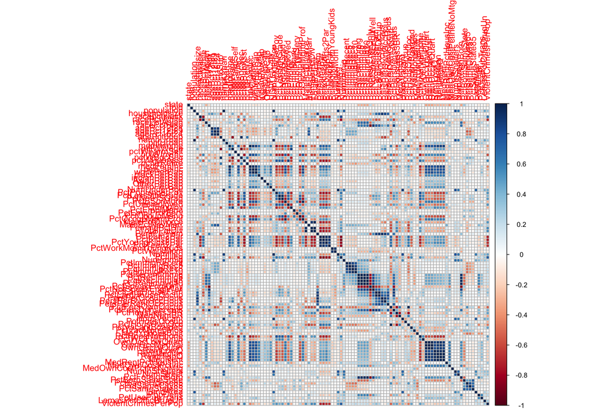

```r
uscrime <- read_csv("Datos_EjemplosClase_Tarea/uscrime.csv")

uscrimeCuantitativas <- dummy.data.frame(uscrime, sep = ";")

azar2 <- sample(1:nrow(uscrime), nrow(uscrime)*0.67)

aprendizajeUscrime <- uscrimeCuantitativas[azar2,]
pruebaUscrime <- uscrimeCuantitativas[-azar2,]

matriz.corrA <- cor(aprendizajeUscrime)
matriz.corrP <- cor(pruebaUscrime)

corrplot(matriz.corrA)
```

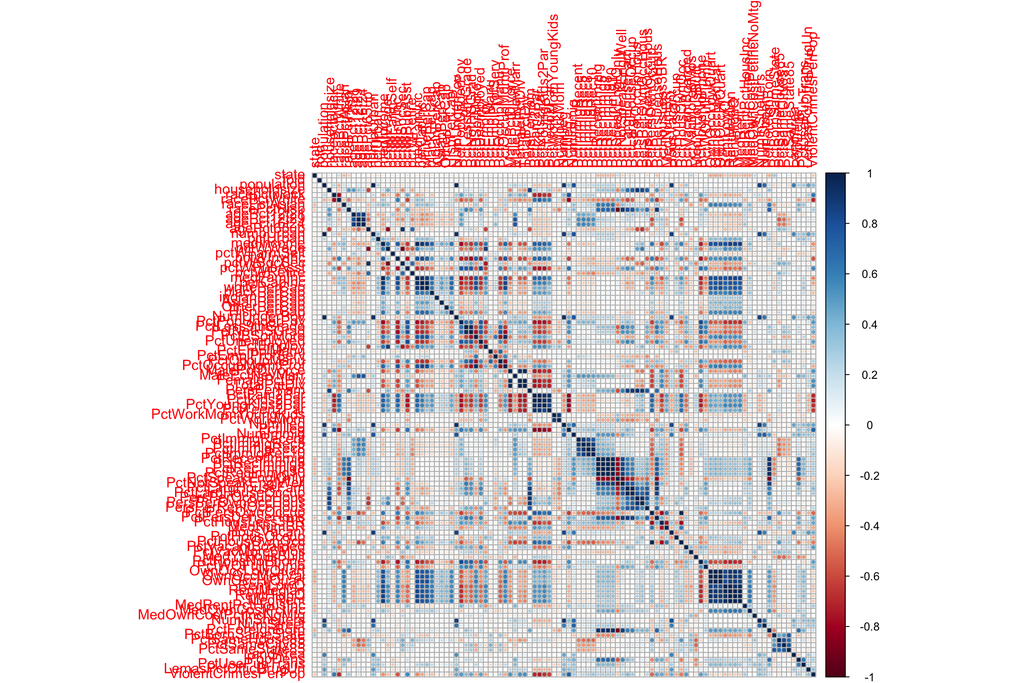

```r
corrplot(matriz.corrP)
```

## 2.

```r
modelo.predictivo <- lm(ViolentCrimesPerPop~ . , data = aprendizajeUscrime)

modelo.predictivo
```

```
Call:
lm(formula = ViolentCrimesPerPop ~ ., data = aprendizajeUscrime)

Coefficients:
        (Intercept)                state                 fold
          0.4194546           -0.0007211           -0.0022471
         population        householdsize         racepctblack
         -0.3463437            0.0576513            0.2188062
       racePctWhite         racePctAsian          racePctHisp
         -0.0054247            0.0057150            0.0676452
        agePct12t21          agePct12t29          agePct16t24
         -0.0320298           -0.2960429            0.0413495
         agePct65up            numbUrban             pctUrban
          0.0647784            0.3037769            0.0262430
          medIncome             pctWWage         pctWFarmSelf
         -0.0811785           -0.3080133            0.0536210
         pctWInvInc           pctWSocSec          pctWPubAsst
         -0.1594252            0.0314792           -0.0687952
         pctWRetire            medFamInc            perCapInc
         -0.0525044            0.1866812            0.3004329
        whitePerCap          blackPerCap         indianPerCap
         -0.4831838           -0.0640858           -0.0083935
        AsianPerCap          OtherPerCap           HispPerCap
         -0.0029224            0.0660050            0.0206024
        NumUnderPov       PctPopUnderPov      PctLess9thGrade
          0.0690997           -0.1024410           -0.0650982
       PctNotHSGrad          PctBSorMore        PctUnemployed
          0.0403082            0.0708540            0.0395444
          PctEmploy          PctEmplManu      PctEmplProfServ
          0.3032851           -0.0598354           -0.0219871
       PctOccupManu     PctOccupMgmtProf       MalePctDivorce
          0.1088201            0.1242957            0.2242960
     MalePctNevMarr         FemalePctDiv          TotalPctDiv
          0.2420089           -0.0675633           -0.0864327
         PersPerFam           PctFam2Par          PctKids2Par
          0.0077489           -0.1449625           -0.1421937
   PctYoungKids2Par          PctTeen2Par  PctWorkMomYoungKids
          0.0280304           -0.0216318            0.0327249
         PctWorkMom             NumIlleg             PctIlleg
         -0.1618915           -0.0588220            0.1741836
           NumImmig       PctImmigRecent         PctImmigRec5
         -0.2516489            0.1074640           -0.0230172
       PctImmigRec8        PctImmigRec10       PctRecentImmig
         -0.1106816            0.0156344           -0.0548964
       PctRecImmig5         PctRecImmig8        PctRecImmig10
         -0.2712653            0.3838039           -0.0398103
   PctSpeakEnglOnly  PctNotSpeakEnglWell      PctLargHouseFam
         -0.0136413           -0.1083705            0.1150811
  PctLargHouseOccup     PersPerOccupHous    PersPerOwnOccHous
         -0.3046321            0.7015654           -0.2355861
 PersPerRentOccHous      PctPersOwnOccup     PctPersDenseHous
         -0.1850483           -0.3694459            0.1035591
     PctHousLess3BR             MedNumBR           HousVacant
          0.0994192            0.0395492            0.1055432
 [ reached getOption("max.print") -- omitted 28 entries ]
```

```r
numero.predictoras <- dim(uscrimeCuantitativas)[2] - 1

#Usando los datos del 85%

prediccion <- predict(modelo.predictivo, pruebaUscrime)

pre.lm <- indices.precision(pruebaUscrime$ViolentCrimesPerPop, prediccion, numero.predictoras)

pre.lm
```

```
$error.cuadratico
[1] 0.01919962

$raiz.error.cuadratico
[1] 0.1508522

$error.relativo
[1] 0.4037535

$correlacion
[1] 0.8093554
```

# Pregunta 4. (Opcional)

## 1.

Programe en R una función lm2(…) que recibe como parámetro una tabla de aprendizaje y retorna un modelo de Regresión Lineal, es decir, calcula y retorna $β = (X^tX)^{−1}X^ty$.

```r
lm2 <- function(y,X){

    b = base::solve(t(X)%*%X) %*% t(X) %*% y

  return(b)
}

x <- as.matrix(Filter(is.numeric, DeudaCredito[-c(1,12)]))

y <- as.matrix(Filter(is.numeric, DeudaCredito[12]))

lm(formula = Balance~., data = DeudaCreditoCuantitativo)
```

```
Call:
lm(formula = Balance ~ ., data = DeudaCreditoCuantitativo)

Coefficients:
               (Intercept)                     Ingreso
                  -43.3535                     -7.8031
                    Limite                 CalifCredit
                    0.1909                      1.1365
                  Tarjetas                        Edad
                   17.7245                     -0.6139
                 Educacion             Genero.Femenino
                   -1.0989                    -10.6532
          Genero.Masculino               Estudiante.No
                        NA                   -425.7474
             Estudiante.Si                      Casado
                        NA                     -8.5339
Etnicidad.Afrodescendiente          Etnicidad.Asiatico
                  -10.1070                      6.6972
       Etnicidad.Caucasico
                        NA
```

```r
lm2(y, x)
```

```
                Balance
Ingreso      -7.0415038
Limite        0.2703146
CalifCredit  -0.3025913
Tarjetas      7.3663705
Edad         -2.7526500
Educacion   -11.9921458
Casado      -51.8778591
```

## 2.

Programe en R una función predict2(…) que recibe como parámetro el modelo construido en la pregunta anterior, una tabla de testing de modo tal que retorna la predicción para esta tabla de testing.

```r
predict2 <- function(m,X){

  resultado <- m*X

  return(resultado)
}

m <- lm2(y, x)



predict2(m, Filter(is.numeric, veintePorcentaje)[,-1])
```

|  | Limite | CalifCredit | Tarjetas | Edad | Educacion | Genero.Femenino | Genero.Masculino | Estudiante.No | Estudiante.Si | Casado | Etnicidad.Afrodescendiente | Etnicidad.Asiatico | Etnicidad.Caucasico | Balance |
| --- | --- | --- | --- | --- | --- | --- | --- | --- | --- | --- | --- | --- | --- | --- |
| 5 | -34482.2441 | 2629.79425 | -103.7557182 | -20.576211 | -191.874333 | 0.0000000 | -2.7526500 | -7.0415038 | 0.000000 | -51.8778591 | 0.0000000 | 0.0000000 | 0.2703146 | -911.12716 |
| 6 | 2175.2214 | -1566.25787 | -28.1660152 | 567.210525 | -518.778591 | 0.0000000 | -11.9921458 | 0.2703146 | 0.000000 | 0.0000000 | 0.0000000 | 0.0000000 | -0.3025913 | -13802.95980 |
| 13 | -1606.1548 | -4724.90544 | 0.2703146 | -156.901052 | -49.290527 | 7.3663705 | 0.0000000 | -0.3025913 | 0.000000 | 0.2703146 | 0.0000000 | -7.0415038 | 0.0000000 | -10583.08326 |
| 14 | 50990.0163 | -26509.58600 | -0.3025913 | -587.615143 | 2.432831 | 0.0000000 | -7.0415038 | 7.3663705 | 0.000000 | -0.3025913 | 0.0000000 | 0.0000000 | -2.7526500 | -7611.86560 |
| 15 | -9058.9713 | -1894.16452 | 14.7327409 | -3890.839432 | -3.933687 | -11.9921458 | 0.0000000 | -2.7526500 | 0.000000 | 0.0000000 | -51.8778591 | 0.0000000 | 0.0000000 | 40.00656 |
| 19 | -76557.8587 | 121.10093 | -2.7526500 | -197.162106 | 66.297334 | -51.8778591 | 0.0000000 | -11.9921458 | 0.000000 | -2.7526500 | 0.0000000 | 7.3663705 | 0.0000000 | -269.60889 |
| 20 | -343742.6944 | -144.94125 | -23.9842916 | 11.893841 | -24.773850 | 0.0000000 | 7.3663705 | -51.8778591 | 0.000000 | 0.0000000 | 0.0000000 | -2.7526500 | 0.0000000 | 7719.95624 |
| 22 | -44910.7112 | 3373.79767 | -51.8778591 | -21.786577 | -203.866478 | 0.2703146 | 0.0000000 | -7.0415038 | 0.000000 | 0.0000000 | 0.0000000 | 0.0000000 | 0.2703146 | -2664.56523 |
| 23 | 711.1977 | -586.31446 | -21.1245114 | 449.348598 | -518.778591 | 0.0000000 | -11.9921458 | 0.2703146 | 0.000000 | -7.0415038 | 7.3663705 | 0.0000000 | 0.0000000 | 0.00000 |
| 27 | -1096.8936 | -3465.73013 | 1.6218875 | -121.116601 | -84.498045 | 7.3663705 | 0.0000000 | 0.0000000 | -11.992146 | 0.0000000 | 0.0000000 | 0.0000000 | 7.3663705 | -33928.11985 |

[output cut: 65 more lines]